# —– B1701 Week 7 | Recruitment Analytics in R | 31.10.23 —–

```r
library(tidyverse)
```

```r
library(corrplot)
library(fmsb)
```

# —– Reading Data —–

```r
cricketdata <- read.csv("/Users/seanmccrone/Desktop/MASTERS DEGREE/Course Material/B1701/Week 7/Practical Data/CricketData.csv")
```

# —– Cleaning Data —–

```r
summary(cricketdata)
```

```
##  Innings.Player      Runs_Scored    Minutes_Batted    Batted_Flag
##  Length:17998       Min.   :  0.0   Min.   :  0.00   Min.   :0.000
##  Class :character   1st Qu.:  2.0   1st Qu.:  9.00   1st Qu.:1.000
##  Mode  :character   Median : 10.0   Median : 24.00   Median :1.000
##                     Mean   : 17.8   Mean   : 36.49   Mean   :0.797
##                     3rd Qu.: 25.0   3rd Qu.: 52.00   3rd Qu.:1.000
##                     Max.   :232.0   Max.   :210.00   Max.   :1.000
##                     NA's   :3653    NA's   :7373
##   Not_Out_Flag     Balls_Faced     Boundary_Fours   Boundary_Sixes
##  Min.   :0.0000   Min.   :  0.00   Min.   : 0.000   Min.   :0.000
##  1st Qu.:0.0000   1st Qu.:  8.00   1st Qu.: 0.000   1st Qu.:0.000
##  Median :0.0000   Median : 20.00   Median : 1.000   Median :0.000
##  Mean   :0.1437   Mean   : 29.69   Mean   : 1.806   Mean   :0.086
##  3rd Qu.:0.0000   3rd Qu.: 43.00   3rd Qu.: 3.000   3rd Qu.:0.000
##  Max.   :1.0000   Max.   :160.00   Max.   :31.000   Max.   :9.000
##                   NA's   :4202     NA's   :4201     NA's   :4201
##  Innings_Number   Opposition           Ground              Date
##  Min.   :1.000   Length:17998       Length:17998       Length:17998
##  1st Qu.:1.000   Class :character   Class :character   Class :character
##  Median :1.000   Mode  :character   Mode  :character   Mode  :character
##  Mean   :1.496
##  3rd Qu.:2.000
##  Max.   :2.000
##  NA's   :154
##    Country              X50.s             X100.s
##  Length:17998       Min.   :0.00000   Min.   :0.000000
##  Class :character   1st Qu.:0.00000   1st Qu.:0.000000
##  Mode  :character   Median :0.00000   Median :0.000000
##                     Mean   :0.06601   Mean   :0.008945
##                     3rd Qu.:0.00000   3rd Qu.:0.000000
##                     Max.   :1.00000   Max.   :1.000000
##
```

```r
head(cricketdata)
```

```
##   Innings.Player Runs_Scored Minutes_Batted Batted_Flag Not_Out_Flag
## 1        A Beggs           0              1           1            0
## 2        A Beggs           0              1           1            1
## 3        A Beggs          NA             NA           0            0
## 4        A Bosch          NA             NA           0            0
## 5        A Bosch          NA             NA           0            0
## 6        A Bosch           6             NA           1            0
##   Balls_Faced Boundary_Fours Boundary_Sixes Innings_Number    Opposition
## 1           2              0              0              1 v India Women
## 2           0              0              0              2    v SA Women
## 3          NA             NA             NA              2    v SA Women
## 4          NA             NA             NA              1   v AUS Women
## 5          NA             NA             NA              2   v AUS Women
## 6           8              0              0              1   v AUS Women
##                Ground       Date            Country X50.s X100.s
## 1 Potchefstroom (Uni) 2017-05-07      Ireland Women     0      0
## 2       Potchefstroom 2017-05-11      Ireland Women     0      0
## 3 Potchefstroom (Uni) 2017-05-19      Ireland Women     0      0
## 4            Canberra 2016-11-18 South Africa Women     0      0
## 5            Canberra 2016-11-20 South Africa Women     0      0
## 6              Sydney 2016-11-23 South Africa Women     0      0
```

```r
str(cricketdata)
```

```
## 'data.frame':    17998 obs. of  15 variables:
##  $ Innings.Player: chr  "A Beggs" "A Beggs" "A Beggs" "A Bosch" ...
##  $ Runs_Scored   : int  0 0 NA NA NA 6 11 17 5 20 ...
##  $ Minutes_Batted: int  1 1 NA NA NA NA NA 42 0 59 ...
##  $ Batted_Flag   : int  1 1 0 0 0 1 1 1 1 1 ...
##  $ Not_Out_Flag  : int  0 1 0 0 0 0 0 0 0 0 ...
##  $ Balls_Faced   : int  2 0 NA NA NA 8 28 37 22 45 ...
##  $ Boundary_Fours: int  0 0 NA NA NA 0 0 3 0 1 ...
##  $ Boundary_Sixes: int  0 0 NA NA NA 0 0 0 0 0 ...
##  $ Innings_Number: int  1 2 2 1 2 1 2 2 2 2 ...
##  $ Opposition    : chr  "v India Women" "v SA Women" "v SA Women" "v AUS Women" ...
##  $ Ground        : chr  "Potchefstroom (Uni)" "Potchefstroom" "Potchefstroom (Uni)" "Canberra" ...
##  $ Date          : chr  "2017-05-07" "2017-05-11" "2017-05-19" "2016-11-18" ...
##  $ Country       : chr  "Ireland Women" "Ireland Women" "Ireland Women" "South Africa Women" ...
##  $ X50.s         : int  0 0 0 0 0 0 0 0 0 0 ...
##  $ X100.s        : int  0 0 0 0 0 0 0 0 0 0 ...
```

# Converting ‘Date’ to date, from a character

```r
cricketdata$Date <- as.Date(cricketdata$Date)
```

# Converting ‘Country’ to factor, from character

```r
cricketdata$Country <- as.factor(cricketdata$Country)
```

# —– Exploratory Analysis —–

# Code to sort the ‘Runs_Scored’ variable in descending order

```r
cricketdata %>%
  arrange(desc(Runs_Scored)) %>%
  head(5)
```

```
##   Innings.Player Runs_Scored Minutes_Batted Batted_Flag Not_Out_Flag
## 1        AC Kerr         232            195           1            1
## 2      DB Sharma         188            195           1            0
## 3   AC Jayangani         178             NA           1            1
## 4         H Kaur         171            143           1            1
## 5      SR Taylor         171            194           1            0
##   Balls_Faced Boundary_Fours Boundary_Sixes Innings_Number  Opposition
## 1         145             31              2              1 v Ire Women
## 2         160             27              2              1 v Ire Women
## 3         143             22              6              1 v AUS Women
## 4         115             20              7              1 v AUS Women
## 5         137             18              2              1  v SL Women
##          Ground       Date           Country X50.s X100.s
## 1        Dublin 2018-06-13 New Zealand Women     0      1
## 2 Potchefstroom 2017-05-15       India Women     0      1
## 3       Bristol 2017-06-29   Sri Lanka Women     0      1
## 4         Derby 2017-07-20       India Women     0      1
## 5        Mumbai 2013-02-03 West Indies Women     0      1
```

# Code to create a correlation table using the ‘cor’ function. Name the variable ‘correlation_matrix’

```r
correlation_matrix <- cor(cricketdata[,c("Runs_Scored", "Minutes_Batted", "Balls_Faced")], use = "complete.obs")
```

# Code to create a correlation plot

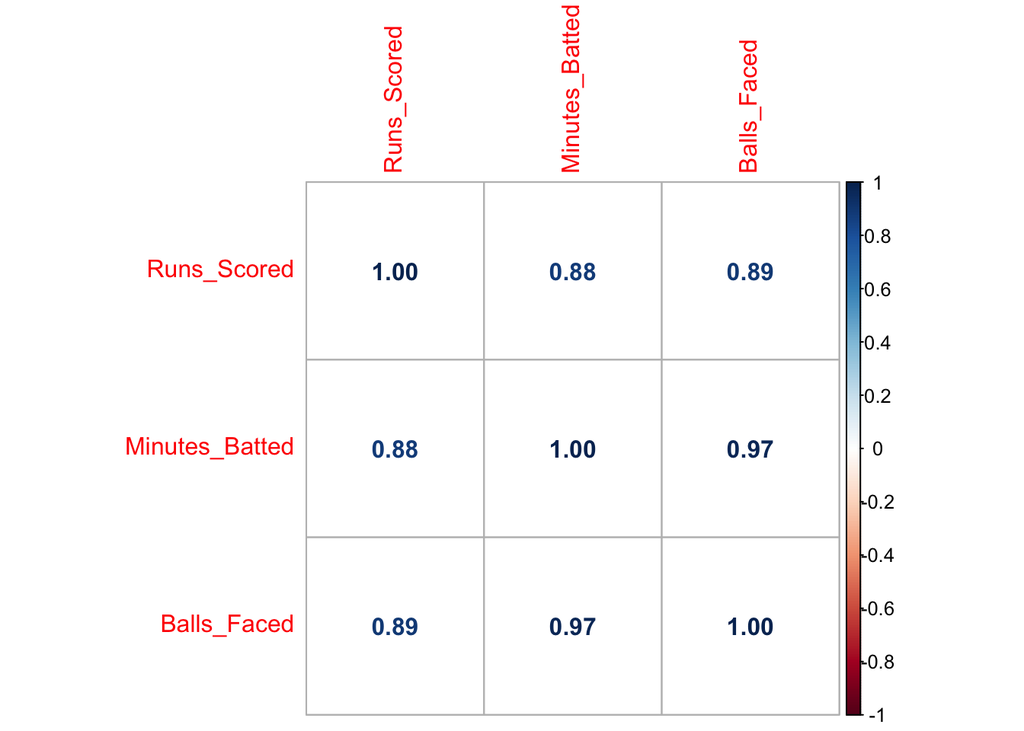

```r
corrplot::corrplot(correlation_matrix, method = "number")
```

# Code to create a scatter plot of Runs Scored vs Balls Faced

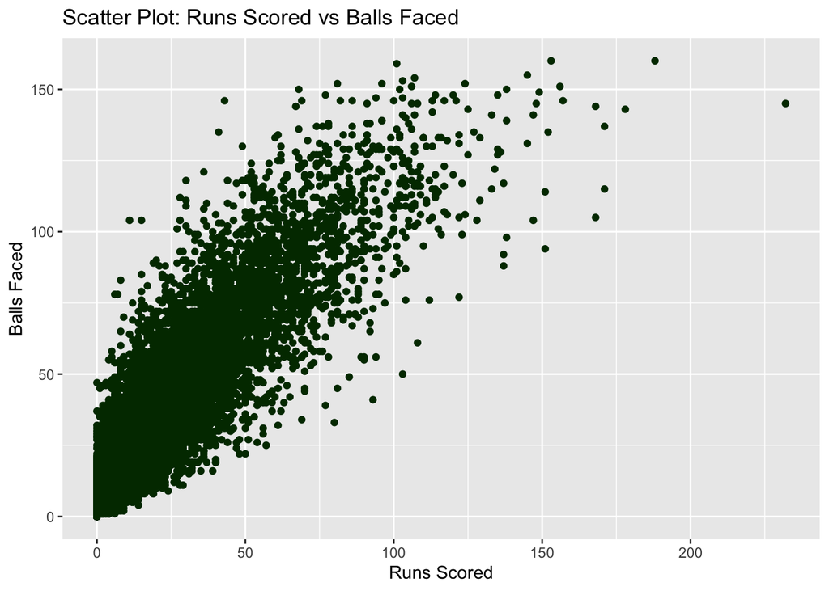

```r
scatRsBf <- ggplot(cricketdata, aes(x = Runs_Scored, y = Balls_Faced)) +
  geom_point(color = "#003300") +
  labs(x = "Runs Scored", y = "Balls Faced") +
  ggtitle("Scatter Plot: Runs Scored vs Balls Faced")
scatRsBf
```

# Code to create a scatter plot of Runs Scored vs Minutes Batted

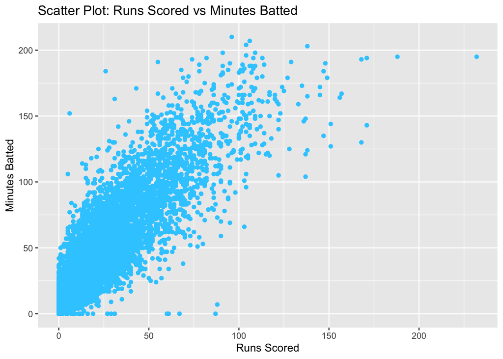

```r
scatRsMb <- ggplot(cricketdata, aes(x = Runs_Scored, y = Minutes_Batted)) +
  geom_point(color = "#33CCFF") +
  labs(x = "Runs Scored", y = "Minutes Batted") +
  ggtitle("Scatter Plot: Runs Scored vs Minutes Batted")
scatRsMb
```

# Code to give information about the function you want to use regarding the two above

```r
?corrplot
```

##### Summarising Data by Player

# Code to provide summary of the data by player; grouped by innings, then summarised

```r
summary_data <- cricketdata %>%
  group_by(Innings.Player) %>%
  summarize(
    Runs_ScoredTotal = sum(Runs_Scored,na.rm=TRUE),
    Minutes_BattedTotal = sum(Minutes_Batted,na.rm=TRUE),
    MatchesTotal = sum(Batted_Flag, na.rm=TRUE),
    Not_Out_FlagTotal = sum(Not_Out_Flag,na.rm=TRUE),
    Balls_FacedTotal = sum(Balls_Faced,na.rm=TRUE),
    Boundary_FoursTotal =sum(Boundary_Fours,na.rm=TRUE),
    Boundary_SixesTotal =sum(Boundary_Sixes,na.rm=TRUE),
    Total_InningsTotal =sum(!is.na(Runs_Scored)),
    X501 =sum(X50.s,na.rm=TRUE),
    X1001=sum(X100.s,na.rm=TRUE),

    Runs_ScoredPerMatch = mean(Runs_Scored,na.rm=TRUE),
    Minutes_BattedPerMatch = mean(Minutes_Batted,na.rm=TRUE),
    Not_OutPerMatch = mean(Not_Out_Flag,na.rm=TRUE),
    Balls_FacedPerMatch = mean(Balls_Faced,na.rm=TRUE),
    Boundary_FoursPerMatch=mean(Boundary_Fours,na.rm=TRUE),
    Boundary_SixesPerMatch=mean(Boundary_Sixes,na.rm=TRUE),
    X50PerMatch=mean(X50.s,na.rm=TRUE),
    X100PerMatch=mean(X100.s,na.rm=TRUE),
  )
```

# Code to provide a data set of the filtered summary

```r
filtsummarydata <- summary_data %>%
  filter(MatchesTotal > 19) %>%
  arrange(desc(Runs_ScoredPerMatch)) %>%
  head(5)
filtsummarydata
```

```
## # A tibble: 5 × 19
##   Innings.Player Runs_ScoredTotal Minutes_BattedTotal MatchesTotal
##   <chr>                     <int>               <int>        <int>
## 1 MM Lanning                 3693                3021           80
## 2 S Mandhana                 2025                3059           51
## 3 SR Taylor                  4754                6266          123
## 4 SW Bates                   4534                6170          118
## 5 L Wolvaardt                1871                3092           49
## # ℹ 15 more variables: Not_Out_FlagTotal <int>, Balls_FacedTotal <int>,
## #   Boundary_FoursTotal <int>, Boundary_SixesTotal <int>,
## #   Total_InningsTotal <int>, X501 <int>, X1001 <int>,
## #   Runs_ScoredPerMatch <dbl>, Minutes_BattedPerMatch <dbl>,
## #   Not_OutPerMatch <dbl>, Balls_FacedPerMatch <dbl>,
## #   Boundary_FoursPerMatch <dbl>, Boundary_SixesPerMatch <dbl>,
## #   X50PerMatch <dbl>, X100PerMatch <dbl>
```

# Code to create a new table showing the players in top 10, who have played 19 matches

```r
top10Runs <- summary_data %>%
  filter(MatchesTotal > 19) %>%
  arrange(desc(Runs_ScoredPerMatch)) %>%
  slice(1:10)
```

# Code to create a bar chart of those in top 10 runs with colours, numbers and names

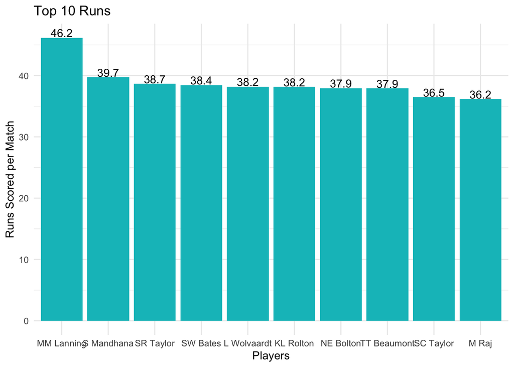

```r
top10Runsplot <- ggplot(top10Runs, aes(x = reorder(Innings.Player, -Runs_ScoredPerMatch), y = Runs_ScoredPerMatch)) +
  geom_bar(stat = "identity", fill = "#00BFC4") +
  ggtitle("Top 10 Runs") +
  geom_text(aes(label = round(Runs_ScoredPerMatch,1), vjust = -0.1)) +
  theme(axis.text.x = element_text(angle = 60, hjust = 1),
        plot.title =  element_text(hjust = 0.5, colour = "Black", size = 20)) +
  labs(x = "Players",
       y = "Runs Scored per Match") +
  theme_minimal()
top10Runsplot
```

# Code to create data set with all the match by match data for our 10 top performing players.

```r
top10playernames <- top10Runs$Innings.Player
top10playerdata <- cricketdata %>%
  filter(Innings.Player %in% top10playernames)
```

# Box plot of scores for each top 10 player

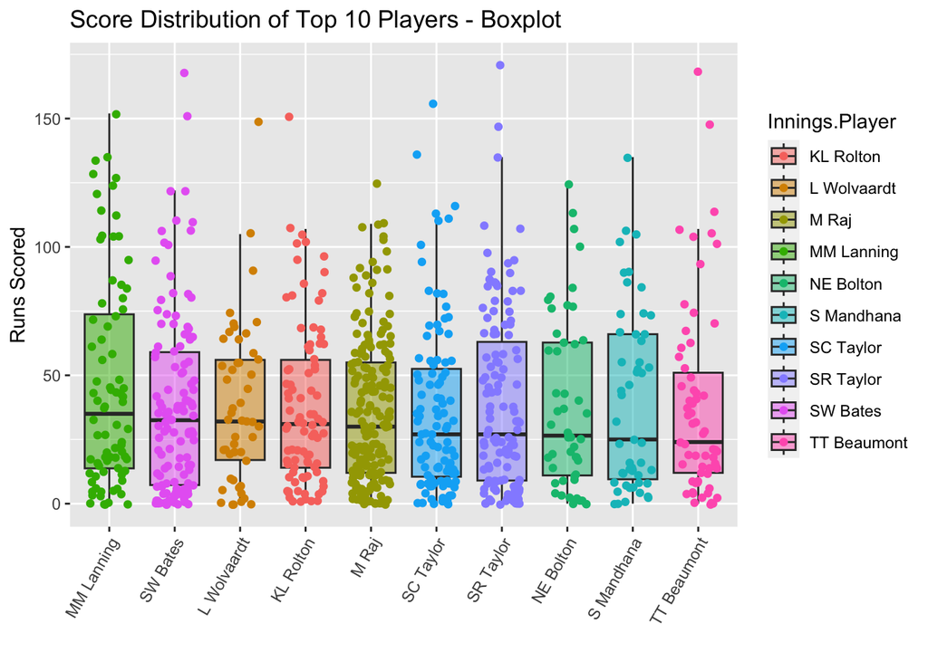

```r
BPT10 <- ggplot(top10playerdata, aes(x =fct_reorder(Innings.Player, Runs_Scored, .desc=TRUE), y = Runs_Scored)) +
  geom_boxplot(alpha = 0.5, outlier.colour = NA, aes(fill = Innings.Player)) +
  theme(axis.text.x = element_text(angle = 60, hjust = 1)) +
  geom_jitter(width = 0.3, aes(color = Innings.Player)) +
  ggtitle("Score Distribution of Top 10 Players - Boxplot") +
  labs(x = "", y = "Runs Scored")
print(BPT10)
```

# Histogram of scores for each top 10 player

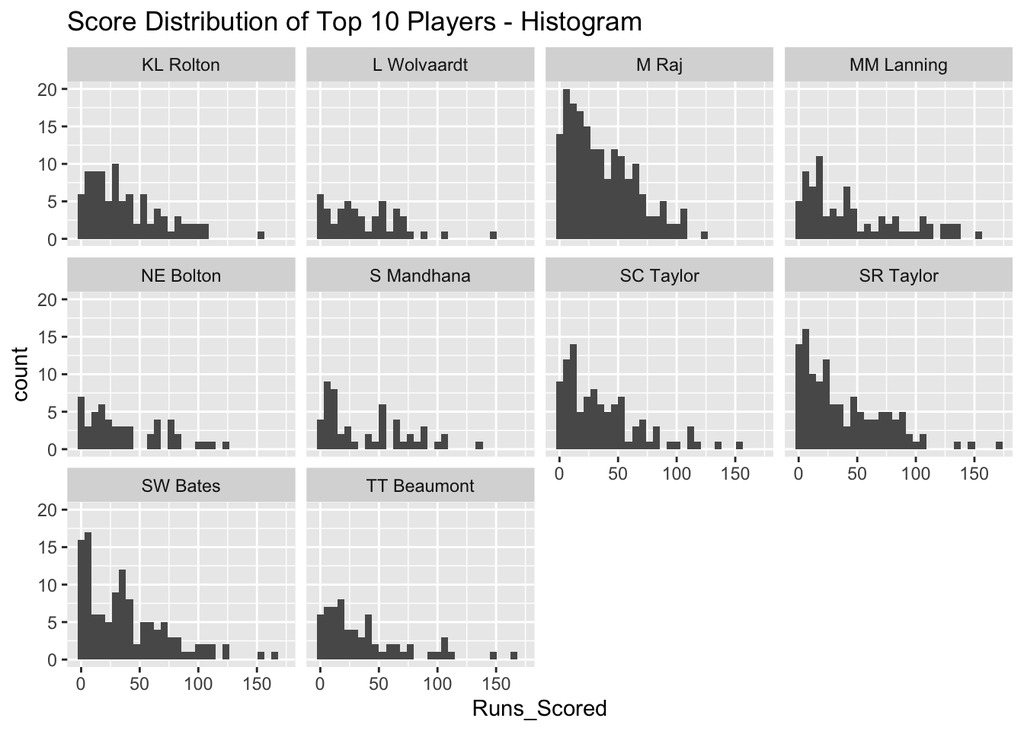

```r
HPT10 <- ggplot(top10playerdata, aes(x = Runs_Scored)) +
  geom_histogram() +
  ggtitle("Score Distribution of Top 10 Players - Histogram") +
  facet_wrap(~Innings.Player)
print(HPT10)
```